# College Admissions, Part 3

Homework

Prof. Bisbee

Due Date: 2023-03-27

Once we have a model that can predict an outcome, we can also run some simulations using our existing data to understand what would happen if we implemented different policies. In this class we’re going to go over how to generate predictions using hypothetical data at different levels of complexity. This is helpful to understand the implications of different models. It’s particularly helpful in the context of logistic regression, as the coefficients from a logistic regression are difficult to understand on their own. Once we feel like we have a handle on the relationship between the variables and the outcome, we can try changing policies to see what the new predictions might look like.

We’ll start by loading in our standard libraries, plus the `modelr` library, and getting the data set up.

```r
library(modelr)
library(tidyverse)
library(tidymodels)
```

```r
ad<-read_rds("../data/admit_data.rds")
```

## Data Wrangling

```r
ad<-ad%>%
  mutate(yield_f=as_factor(ifelse(yield==1,"Yes","No")))%>%
  mutate(yield_f=relevel(yield_f,ref="No"))%>%
    mutate(sat=sat/100,
         income=income/1000,
         distance=distance/1000,
         net_price=net_price/1000)
```

## Settting the Model

Today I’m going to use a more fully specified logit model. We’ll include most of the variables in the dataset, then fit the model and take a look at the coefficients.

```r
admit_formula <- as.formula(
                  "yield_f~
                          legacy+
                          visit+
                          registered+
                          sent_scores+
                          sat+
                          income+
                          gpa+
                          distance+
                          net_price")
```

## Fit the Model

```r
m <- glm(formula = admit_formula,
         family = binomial(link = 'logit'),
         data = ad)
tidy(m) # Easier to read regression output (same as summary(m))
```

```
## # A tibble: 10 × 5
##    term        estimate std.error statistic  p.value
##    <chr>          <dbl>     <dbl>     <dbl>    <dbl>
##  1 (Intercept)  -8.96     1.52       -5.89  3.87e- 9
##  2 legacy        0.514    0.153       3.35  8.11e- 4
##  3 visit         0.285    0.135       2.11  3.53e- 2
##  4 registered    0.461    0.132       3.50  4.64e- 4
##  5 sent_scores   0.730    0.179       4.08  4.48e- 5
##  6 sat          -0.0444   0.126      -0.352 7.25e- 1
##  7 income        0.0513   0.00311    16.5   3.10e-61
##  8 gpa           1.77     0.337       5.26  1.41e- 7
##  9 distance     -1.53     0.346      -4.41  1.04e- 5
## 10 net_price    -0.0559   0.00761    -7.35  1.93e-13
```

## Current Institutional Policies

(This is a recap from lecture 1)

Essentially every private college engages heavily in tuition discounting. This has two basic forms: need-based aid and merit-based aid. Need-based aid is provided on the basis of income, typically with some kind of income cap. Merit-based aid is based on demonstrated academic qualifications, again usually with some kind of minimum. Here’s this institution’s current policies.

The institution is currently awarding need-based aid for families making less than $100,0000 on the following formula:

$need_aid=500+(income/1000-100)\*-425$

Translated, this means for every $1,000 the family makes less than $100,000 the student receives an additional 425 dollars. So for a family making $50,000, need-based aid will be $500+(50,000/1000-100)*-425= 500+ (-50*-425)$=$21,750. Need based aid is capped at total tuition.

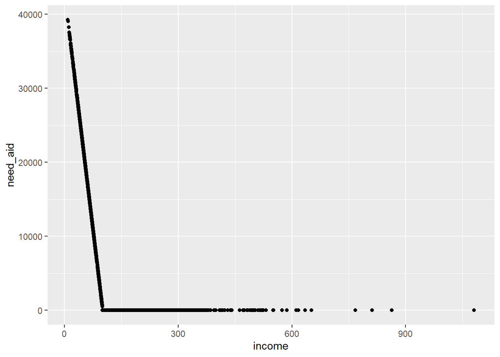

```r
ad%>%
  ggplot(aes(x=income,y=need_aid))+
  geom_point()
```

$merit_aid=500+(sat/10\*250)$

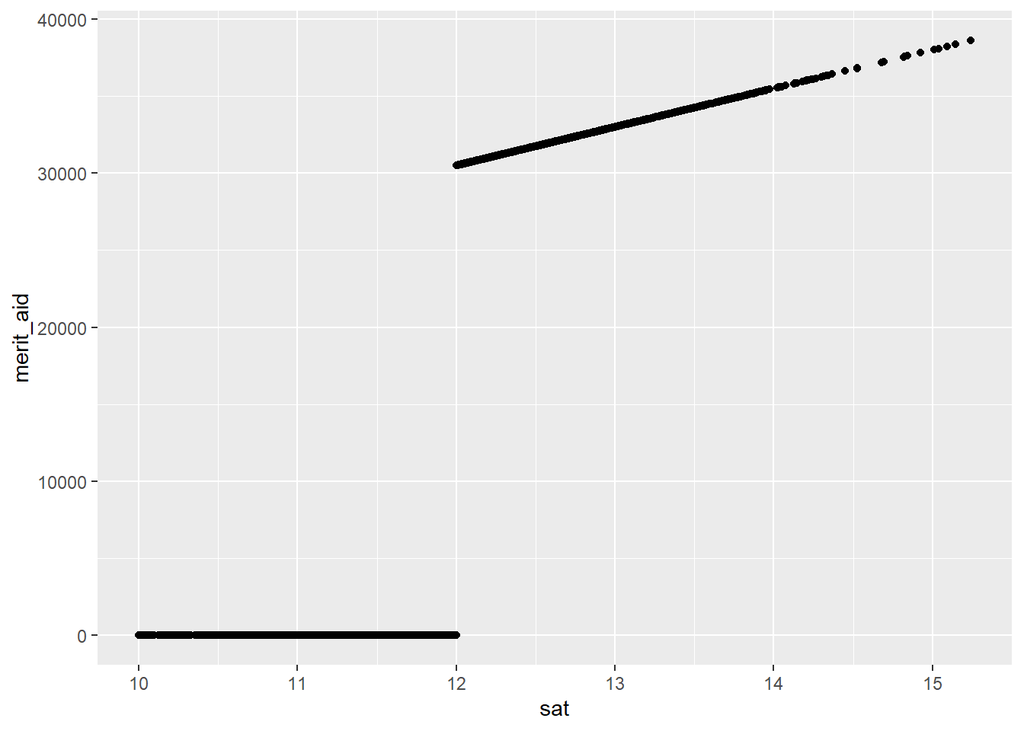

```r
ad%>%
  ggplot(aes(x=sat,y=merit_aid))+
  geom_point()
```

## Probability for a Specific Case

According to our policy, someone with this set of characteristics would receive

$need_aid=500+(income/1000-100)\*-425$= 2625 in need-based aid, and

$merit_aid=500+(sat/10\*250)$= 35,500 in merit based aid, so their net price would be:

45000-2625-35,500= 6,875

We will use the `data_grid` command. This command allows us to specify values of the covariates in a model so that we can then use these to get a predicted probability from the model.

```r
hypo_data <- ad %>%
  data_grid(legacy=0,
            visit=1,
            registered=1,
            sent_scores=1,
            sat=14,
            income=95,
            gpa=3.9,
            distance=.1,
            net_price=6.875
            )
```

```r
data.frame(prob_attend = predict(m,newdata = hypo_data,type="response")) %>%
  bind_cols(hypo_data)
```

```
##   prob_attend legacy visit registered sent_scores sat income gpa distance
## 1   0.9587473      0     1          1           1  14     95 3.9      0.1
##   net_price
## 1     6.875
```

*Quick Exercise:* What’s the probability that the same student would attend if we increased their net price by 10k?

```r
# INSERT CODE HERE
```

## Change in Probability for Two Cases

With the data_grid command, we can ask for results back for many combinations of values. Let’s check to see what happens in the above case if we compare individuals who did and did not send their scores.

```r
hypo_data <- ad %>%
  data_grid(legacy=0,
            visit=1,
            registered=1,
            sent_scores=c(0,1),
            sat=14,
            income=95,
            gpa=3.9,
            distance=.1,
            net_price=6.875
            )
```

```r
data.frame(prob_attend = predict(m,newdata = hypo_data,type="response")) %>%
  bind_cols(hypo_data)
```

```
##   prob_attend legacy visit registered sent_scores sat income gpa distance
## 1   0.9180167      0     1          1           0  14     95 3.9      0.1
## 2   0.9587473      0     1          1           1  14     95 3.9      0.1
##   net_price
## 1     6.875
## 2     6.875
```

*Quick Exercise:* What’s the difference in probability for students who did and didn’t visit campus

```r
# INSERT CODE HERE
```

## Using Default Values

One really powerful aspect of `data_grid` is that we don’t have to specify the value of every variable. Instead, we can use supply the model to data_grid and it will use the default values. Let’s say we just want a prediction for someone with mean or modal value for all of the characteristics. We can use data_grid with the model argument to get this:

```r
hypo_data <- ad %>%
  data_grid(.model=m)
```

```r
data.frame(prob_attend = predict(m,newdata = hypo_data,type="response")) %>%
  bind_cols(hypo_data)
```

```
##   prob_attend legacy visit registered sent_scores      sat   income      gpa
## 1   0.8655441      0     0          1           0 12.00089 99.71213 3.790439
##    distance net_price
## 1 0.1002338  14.10675
```

*Quick Exercise:* generate probabilities for individuals who are both at the mean or mode of all variables, but have a gpa of 3.5 and 3.9.

```r
hypo_data <- ad %>%
  data_grid(.model=m,
            gpa=c(3.5,3.9))

data.frame(prob_attend = predict(m,newdata = hypo_data,type="response")) %>%
  bind_cols(hypo_data)
```

```
##   prob_attend gpa legacy visit registered sent_scores      sat   income
## 1   0.7936923 3.5      0     0          1           0 12.00089 99.71213
## 2   0.8865843 3.9      0     0          1           0 12.00089 99.71213
##    distance net_price
## 1 0.1002338  14.10675
## 2 0.1002338  14.10675
```

## Probabilities Across a Range of Cases

The other thing we can do is to generate probabilities for a range of a continuous variable. The `seq_range` variable allows us to go from the minimum to the maximum of a given variable in a specified number of steps. Below I go from the minimum gpa to the maximum gpa in 100 steps, for both legacy and non-legacy students, with all other values held at their mean or mode.

```r
hypo_data <- ad %>%
  data_grid(gpa = seq_range(gpa, n = 100),
            legacy=c(0,1),
            .model=m)
```

We can then plot that data as follows:

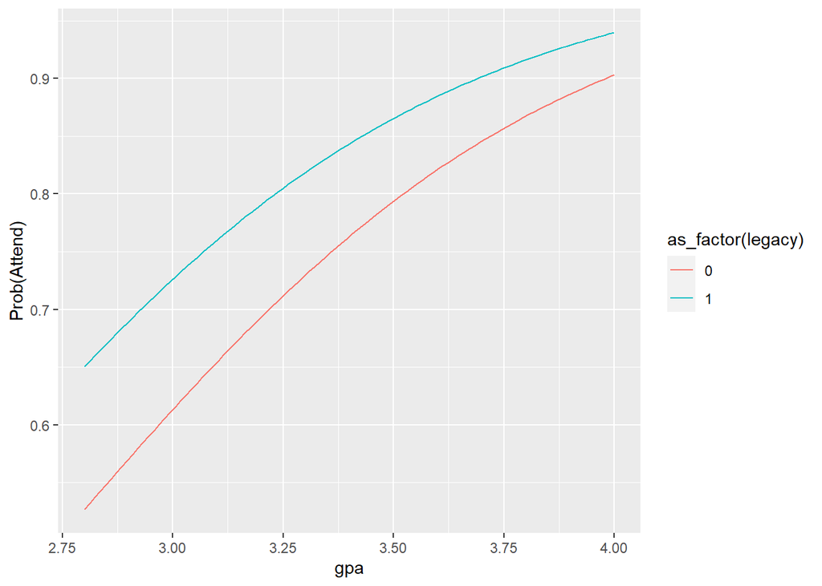

```r
plot_data<-data.frame(prob_attend = predict(m,newdata = hypo_data,type="response")) %>%
  bind_cols(hypo_data)

plot_data%>%
ggplot(aes(x=gpa,y=prob_attend,color=as_factor(legacy)))+
  geom_line()+
  ylab("Prob(Attend)")
```

*Quick Exercise:* Plot the impact of changing distance across its range for those who have and haven’t visited campus

```r
# INSERT CODE HERE
```

The above tools can allow us to think through the substantive importance of changes in the different variables. This is an important step in these kinds of models, where the coefficients aren’t directly interpretable.

## Changing policy

AS we think about changing policy for the campus, we need to answer a series of questions about the key characteristics of the campus right now. Remember that for your assignment we want you to do the the four following things:

1. Increase the average SAT score to 1300
2. Admit at least 200 more students with incomes less than $50,000
3. Don’t allow tuition revenues from first-year students to drop to less than $30 million
4. Keep the number of enrolled students between 1,450 and 1,550

So, what’s the average SAT score?

```r
ad%>%
  filter(yield==1)%>%
  summarize(mean(sat))
```

```
##   mean(sat)
## 1  12.25941
```

Second, how many currently enrolled students come from families that make less than $50,000 a year?

```r
ad%>%
  filter(yield==1,income<50)%>%
  count()
```

```
##    n
## 1 77
```

[Someone alert Raj Chetty!](https://www.nytimes.com/interactive/projects/college-mobility/vanderbilt-university)

Next how much does the campus collect from first-year students in tuition revenue?

```r
ad%>%
  filter(yield==1)%>%
  summarize(dollar(sum(net_price)))
```

```
##   dollar(sum(net_price))
## 1             $30,674.15
```

And how many students currently yield?

```r
ad%>%
  filter(yield==1)%>%
  count()
```

```
##      n
## 1 1466
```

What we want to do now is to think about how changing policies might affect all four of these summary measures. Let’s think about changing our financial aid policy for students who sent scores.

```r
data.frame(prob_attend = predict(m,type = 'response')) %>%
  bind_cols(ad)%>%
  mutate(pred_attend = ifelse(prob_attend > .5,1,0)) %>%
  group_by(sent_scores,pred_attend)%>%
  count()
```

```
## # A tibble: 4 × 3
## # Groups:   sent_scores, pred_attend [4]
##   sent_scores pred_attend     n
##         <dbl>       <dbl> <int>
## 1           0           0   627
## 2           0           1  1093
## 3           1           0    75
## 4           1           1   355
```

The model currently predicts that 355 of the 430 students who sent scores will enroll. What happens if we increase their net price by 5,000? I’m going to create a new version of our dataset, with net price increased by 5,000 (5) for everyone who sent scores.

```r
ad_np<-ad%>%
  mutate(net_price=ifelse(sent_scores==1,
                              net_price+5,
                              net_price))
```

Then I can generate predictions from the dataset, and create a new variable for `prob_attend` which will classify our variable. Please note that this uses a threshold of .5 by default.

```r
ad_np<-data.frame(prob_attend = predict(m,newdata = ad_np,type = 'response')) %>%
  mutate(pred_attend = ifelse(prob_attend > .5,1,0)) %>%
  bind_cols(ad_np)
```

How many students who sent scores are now predicted to yield?

```r
ad_np%>%
  group_by(sent_scores,pred_attend)%>%
  count()
```

```
## # A tibble: 4 × 3
## # Groups:   sent_scores, pred_attend [4]
##   sent_scores pred_attend     n
##         <dbl>       <dbl> <int>
## 1           0           0   627
## 2           0           1  1093
## 3           1           0    92
## 4           1           1   338
```

```r
ad_np%>%
  filter(pred_attend==1)%>%
  summarize(dollar(sum(net_price)))
```

```
##   dollar(sum(net_price))
## 1             $31,264.66
```

Total revenues went up!

And what happened to overall enrollment?

```r
ad_np%>%
  group_by(pred_attend)%>%
  count()
```

```
## # A tibble: 2 × 2
## # Groups:   pred_attend [2]
##   pred_attend     n
##         <dbl> <int>
## 1           0   719
## 2           1  1431
```

So, this policy decreased enrollment slightly, but raised 500,000 dollars. Worth it?

*Quick Exercise:* Decrease prices for everyone who lives more than 1500 miles away by 10,000 and summarize the impacts on the campus.

```r
# INSERT CODE HERE
```